# Missing Value Imputation

Liu Wenhui Singh Ravi

3/31/2018

## A. Missing Value Detection

#### A.1 Data preparation

```r
suppressPackageStartupMessages({
library(Hmisc)
library(dplyr)
library(mice)
library(tidyr)
library(ggplot2)
library(purrr)
library(VIM)
library(magrittr)
library(corrplot)
})
```

```r
air <- read.csv('BeijingPM20100101_20151231.csv')
air %<>% rename(PM_Dongsih= PM_Dongsihuan)%<>% rename(PM_Nongzh=PM_Nongzhanguan)
summary(air)
```

```
##        No             year          month             day
##  Min.   :    1   Min.   :2010   Min.   : 1.000   Min.   : 1.00
##  1st Qu.:13147   1st Qu.:2011   1st Qu.: 4.000   1st Qu.: 8.00
##  Median :26292   Median :2012   Median : 7.000   Median :16.00
##  Mean   :26292   Mean   :2012   Mean   : 6.524   Mean   :15.73
##  3rd Qu.:39438   3rd Qu.:2014   3rd Qu.:10.000   3rd Qu.:23.00
##  Max.   :52584   Max.   :2015   Max.   :12.000   Max.   :31.00
##
##       hour           season        PM_Dongsi        PM_Dongsih
##  Min.   : 0.00   Min.   :1.000   Min.   :  3.00   Min.   :  3.00
##  1st Qu.: 5.75   1st Qu.:1.000   1st Qu.: 24.00   1st Qu.: 28.00
##  Median :11.50   Median :2.000   Median : 64.00   Median : 68.00
##  Mean   :11.50   Mean   :2.491   Mean   : 89.15   Mean   : 92.56
##  3rd Qu.:17.25   3rd Qu.:3.000   3rd Qu.:124.00   3rd Qu.:127.00
##  Max.   :23.00   Max.   :4.000   Max.   :737.00   Max.   :672.00
##                                  NA's   :27532    NA's   :32076
##    PM_Nongzh        PM_US.Post         DEWP              HUMI
##  Min.   :  3.00   Min.   :  1.0   Min.   :-40.000   Min.   :  2.0
##  1st Qu.: 24.00   1st Qu.: 27.0   1st Qu.:-10.000   1st Qu.: 31.0
##  Median : 62.00   Median : 69.0   Median :  2.000   Median : 55.0
##  Mean   : 88.64   Mean   : 95.9   Mean   :  2.075   Mean   : 54.6
##  3rd Qu.:122.00   3rd Qu.:132.0   3rd Qu.: 15.000   3rd Qu.: 78.0
##  Max.   :844.00   Max.   :994.0   Max.   : 28.000   Max.   :100.0
##  NA's   :27653    NA's   :2197    NA's   :5         NA's   :339
##       PRES           TEMP          cbwd            Iws
##  Min.   : 991   Min.   :-19.00   cv  :11412   Min.   :  0.45
##  1st Qu.:1008   1st Qu.:  2.00   NE  : 6178   1st Qu.:  1.79
##  Median :1016   Median : 14.00   NW  :16717   Median :  4.92
##  Mean   :1016   Mean   : 12.59   SE  :18272   Mean   : 23.26
##  3rd Qu.:1025   3rd Qu.: 23.00   NA's:    5   3rd Qu.: 21.02
##  Max.   :1046   Max.   : 42.00                Max.   :585.60
##  NA's   :339    NA's   :5                     NA's   :5
##  precipitation          Iprec
##  Min.   :     0.0   Min.   :     0.0
##  1st Qu.:     0.0   1st Qu.:     0.0
##  Median :     0.0   Median :     0.0
##  Mean   :    19.3   Mean   :    19.5
##  3rd Qu.:     0.0   3rd Qu.:     0.0
##  Max.   :999990.0   Max.   :999990.0
##  NA's   :484        NA's   :484
```

```r
## columns highted by describe result to detect missing value
## PM_Dongsi,PM_Dongsihuan,PM_Nongzhanguan,PM_US.Post,HUMI,PRES,precipitation,Iprec
```

#### A.2 Missing Value Visualization

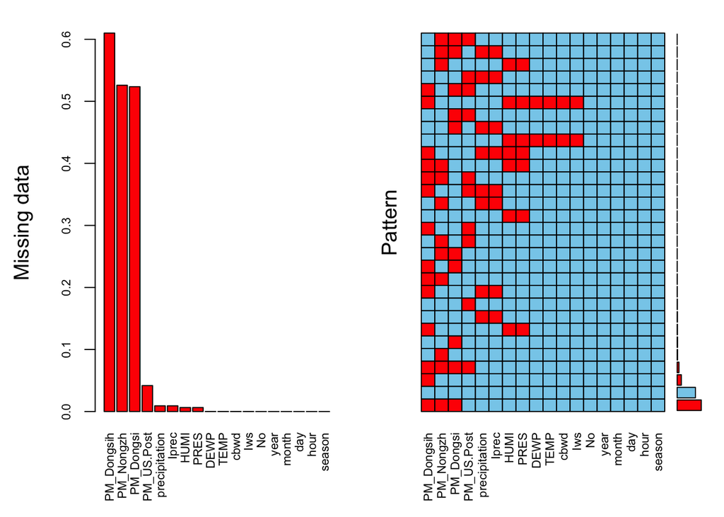

```
##
##  Variables sorted by number of missings:
##       Variable        Count
##     PM_Dongsih 6.099954e-01
##      PM_Nongzh 5.258824e-01
##      PM_Dongsi 5.235813e-01
##     PM_US.Post 4.178077e-02
##  precipitation 9.204321e-03
##          Iprec 9.204321e-03
##           HUMI 6.446828e-03
##           PRES 6.446828e-03
##           DEWP 9.508596e-05
##           TEMP 9.508596e-05
##           cbwd 9.508596e-05
##            Iws 9.508596e-05
##             No 0.000000e+00
##           year 0.000000e+00
##          month 0.000000e+00
##            day 0.000000e+00
##           hour 0.000000e+00
##         season 0.000000e+00
```

```r
mice_plot <- aggr(air, numbers=TRUE, sortVars=TRUE, labels=names(air), cex.axis=0.7, ylab=c("Missing data", "Pattern"))
```

The above graph seems little confusing, but it has lot of info.

For instance, the left block shows:

[output not shown]

### A.2 Before we delve into the nuisances of missign value imputations, lets quickly understand the types of missing value:

- **MCAR** (*Missing Completely at Random*)

It means the missing values are completely random, there is no pattern associated to it. The **Missing** and **Observed** distrubutions will look the same. If we discard these observations, we are not inducing any bias into our analysis. However, one has to be very careful before deleting missing values. If the missing data is less than **0.5%**, then it is safe to delete it, or else one must impute it.

- **MAR** (*Missing at Random*)

It means there is a significant difference between **Missing** and **Observed** distributions, and the pattern can be explained by other observed variables. One way is to run regression individually on each variables (that contains missing value) as response variables, or use the nice **mice** package from R.

- **MNAR** (*Missing not at random*)

This is the most toughest category to impute, generally people delete such columns. For instance, in a survey people with high income left the income column blank. There is no way we can impute such values, because the missing values is dependent on one segment of our income variable, which cannot be imputed. However in such scenarios, it is sometimes advisable to bin the income variable into several buckets, and categorize them into 1 to 5.

### A.3 Understand the missing value pattern

#### A.3.1 Margin Plot

- It is very helpful in determining if the values are MAR or MCAR
- The margin plot, plots 2 features at a time, and contains box plot & scatter plot

##### Lets plot PM_Dongsih and PM_Nongzh and interpret the graph

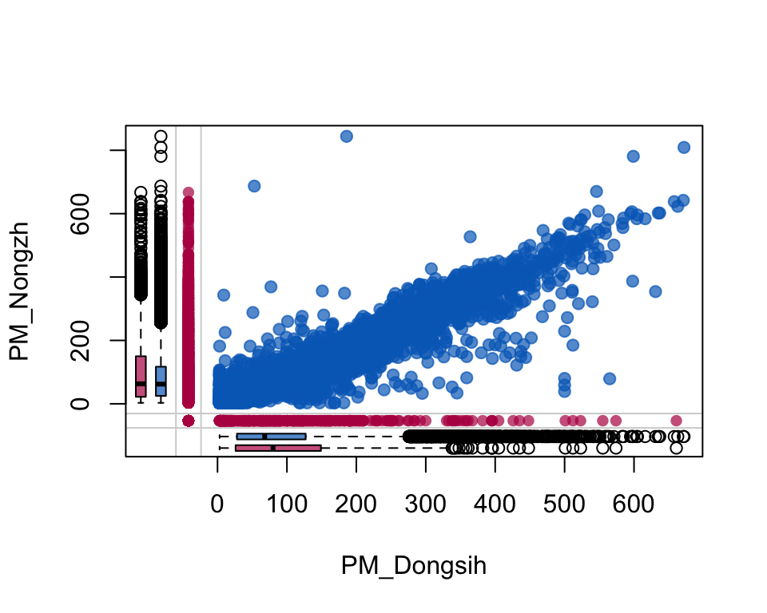

```r
marginplot(air[, c("PM_Dongsih", "PM_Nongzh")], col = mdc(1:2), cex.numbers = 1.2, pch = 19)
```

The *red points* displays *missing values* and similarly *blue points* displays *non-missing values*

#### A.3.2 Margin Matrix

This plot is simlar to the Margin Plot we discussed above, however one can use multiple variables at a time to give wide perspective.

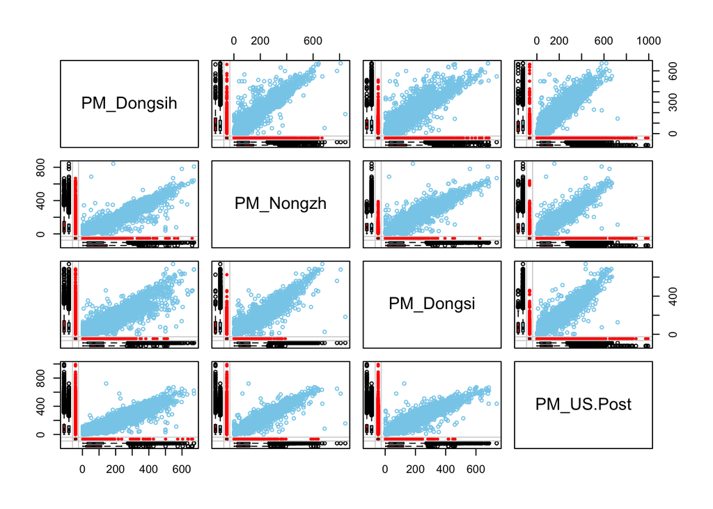

```r
marginmatrix(air[,c("PM_Dongsih", "PM_Nongzh","PM_Dongsi","PM_US.Post")])
```

#### A.3.3 Correlation

We can use correlation to understand the relation between the varibales that have missing values.

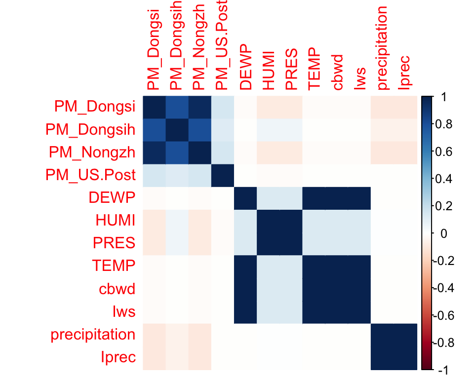

```r
## 1 if the value in air is missing and 0 if the value is non missing
air.missing <- as.data.frame(abs(is.na(air)))

air.missing.few.col <- air.missing[,sapply(air.missing, sd)>0]
corrplot(cor(air.missing.few.col),method ="color")
```

The corrplot shows extreme correlation between the variables. For example: - PM_Dongsi is correlated to PM_Dongsih & PM_Nongzh - DEWP is correlated to TEMP, cbwd & IWS.